# Predicting the Risk of Stroke in Patients Using R

## Introduction

Stroke is a major cause of death and disability worldwide, and it is important to identify risk factors that can help predict the likelihood of a stroke occurring. In this project, we will use R to analyze a dataset containing information on various patient characteristics, including age, gender, hypertension, heart disease, and other factors, to determine whether these factors can be used to predict the risk of stroke. By understanding the relationship between these variables and the risk of stroke, we can potentially develop strategies for preventing or mitigating this serious health condition. The goal of this project is to use R programming to analyze the data and determine which factors are most closely associated with an increased risk of stroke.

# Reading the data

```r
data <- read.csv("stroke.csv")
head(data)
```

```
##      id gender age hypertension heart_disease ever_married     work_type
## 1  9046   Male  67            0             1          Yes       Private
## 2 51676 Female  61            0             0          Yes Self-employed
## 3 31112   Male  80            0             1          Yes       Private
## 4 60182 Female  49            0             0          Yes       Private
## 5  1665 Female  79            1             0          Yes Self-employed
## 6 56669   Male  81            0             0          Yes       Private
##   Residence_type avg_glucose_level  bmi  smoking_status stroke
## 1          Urban            228.69 36.6 formerly smoked      1
## 2          Rural            202.21  N/A    never smoked      1
## 3          Rural            105.92 32.5    never smoked      1
## 4          Urban            171.23 34.4          smokes      1
## 5          Rural            174.12   24    never smoked      1
## 6          Urban            186.21   29 formerly smoked      1
```

# Summary Statistics

```r
summary(data)
```

```
##        id           gender               age         hypertension
##  Min.   :   67   Length:5110        Min.   : 0.08   Min.   :0.00000
##  1st Qu.:17741   Class :character   1st Qu.:25.00   1st Qu.:0.00000
##  Median :36932   Mode  :character   Median :45.00   Median :0.00000
##  Mean   :36518                      Mean   :43.23   Mean   :0.09746
##  3rd Qu.:54682                      3rd Qu.:61.00   3rd Qu.:0.00000
##  Max.   :72940                      Max.   :82.00   Max.   :1.00000
##  heart_disease     ever_married        work_type         Residence_type
##  Min.   :0.00000   Length:5110        Length:5110        Length:5110
##  1st Qu.:0.00000   Class :character   Class :character   Class :character
##  Median :0.00000   Mode  :character   Mode  :character   Mode  :character
##  Mean   :0.05401
##  3rd Qu.:0.00000
##  Max.   :1.00000
##  avg_glucose_level     bmi            smoking_status         stroke
##  Min.   : 55.12    Length:5110        Length:5110        Min.   :0.00000
##  1st Qu.: 77.25    Class :character   Class :character   1st Qu.:0.00000
##  Median : 91.89    Mode  :character   Mode  :character   Median :0.00000
##  Mean   :106.15                                          Mean   :0.04873
##  3rd Qu.:114.09                                          3rd Qu.:0.00000
##  Max.   :271.74                                          Max.   :1.00000
```

```r
str(data)
```

```
## 'data.frame':    5110 obs. of  12 variables:
##  $ id               : int  9046 51676 31112 60182 1665 56669 53882 10434 27419 60491 ...
##  $ gender           : chr  "Male" "Female" "Male" "Female" ...
##  $ age              : num  67 61 80 49 79 81 74 69 59 78 ...
##  $ hypertension     : int  0 0 0 0 1 0 1 0 0 0 ...
##  $ heart_disease    : int  1 0 1 0 0 0 1 0 0 0 ...
##  $ ever_married     : chr  "Yes" "Yes" "Yes" "Yes" ...
##  $ work_type        : chr  "Private" "Self-employed" "Private" "Private" ...
##  $ Residence_type   : chr  "Urban" "Rural" "Rural" "Urban" ...
##  $ avg_glucose_level: num  229 202 106 171 174 ...
##  $ bmi              : chr  "36.6" "N/A" "32.5" "34.4" ...
##  $ smoking_status   : chr  "formerly smoked" "never smoked" "never smoked" "smokes" ...
##  $ stroke           : int  1 1 1 1 1 1 1 1 1 1 ...
```

# Materials and methods

The dataset was obtained via participation in a Kaggle competition centered on predicting strokes [https://www.kaggle.com/fedesoriano/stroke-prediction-dataset]. The data consists of 5110 observations and 12 variables, including information on patient characteristics such as age, gender, hypertension, and other factors.

In order to predict the risk of stroke, I first split the data into training and test sets using the createDataPartition function from the caret package. I trained a logistic regression model on the training set using the glm function, and evaluated the model’s performance on the test set using the predict function and a variety of evaluation metrics.

Overall, the analysis included a combination of statistical analyses, data visualization, and machine learning techniques to predict the risk of stroke based on patient characteristics.

## Merging the data

First to demonstrate the use of the `merge` function, I will use another dataset for heart prediction also freely available on kaggle. The `merge` function will allow us to combine the two datasets into one. ### read in heart data

```r
heart <- read.csv("heart.csv")
head(heart)
```

```
##   age sex cp trestbps chol fbs restecg thalach exang oldpeak slope ca thal
## 1  63   1  3      145  233   1       0     150     0     2.3     0  0    1
## 2  37   1  2      130  250   0       1     187     0     3.5     0  0    2
## 3  41   0  1      130  204   0       0     172     0     1.4     2  0    2
## 4  56   1  1      120  236   0       1     178     0     0.8     2  0    2
## 5  57   0  0      120  354   0       1     163     1     0.6     2  0    2
## 6  57   1  0      140  192   0       1     148     0     0.4     1  0    1
##   target
## 1      1
## 2      1
## 3      1
## 4      1
## 5      1
## 6      1
```

## Create a common column

Since we dont have a common variable to merge on, I will create a column id in both datasets to demonstrate the merge function.

```r
data$id <- 1:nrow(data)
heart$id <- 1:nrow(heart)
```

```r
head(data)
```

```
##   id gender age hypertension heart_disease ever_married     work_type
## 1  1   Male  67            0             1          Yes       Private
## 2  2 Female  61            0             0          Yes Self-employed
## 3  3   Male  80            0             1          Yes       Private
## 4  4 Female  49            0             0          Yes       Private
## 5  5 Female  79            1             0          Yes Self-employed
## 6  6   Male  81            0             0          Yes       Private
##   Residence_type avg_glucose_level  bmi  smoking_status stroke
## 1          Urban            228.69 36.6 formerly smoked      1
## 2          Rural            202.21  N/A    never smoked      1
## 3          Rural            105.92 32.5    never smoked      1
## 4          Urban            171.23 34.4          smokes      1
## 5          Rural            174.12   24    never smoked      1
## 6          Urban            186.21   29 formerly smoked      1
```

```r
head(heart)
```

```
##   age sex cp trestbps chol fbs restecg thalach exang oldpeak slope ca thal
## 1  63   1  3      145  233   1       0     150     0     2.3     0  0    1
## 2  37   1  2      130  250   0       1     187     0     3.5     0  0    2
## 3  41   0  1      130  204   0       0     172     0     1.4     2  0    2
## 4  56   1  1      120  236   0       1     178     0     0.8     2  0    2
## 5  57   0  0      120  354   0       1     163     1     0.6     2  0    2
## 6  57   1  0      140  192   0       1     148     0     0.4     1  0    1
##   target id
## 1      1  1
## 2      1  2
## 3      1  3
## 4      1  4
## 5      1  5
## 6      1  6
```

## Merge the data

```r
merged <- merge(data, heart, by = "id")
head(merged)
```

```
##   id gender age.x hypertension heart_disease ever_married     work_type
## 1  1   Male    67            0             1          Yes       Private
## 2  2 Female    61            0             0          Yes Self-employed
## 3  3   Male    80            0             1          Yes       Private
## 4  4 Female    49            0             0          Yes       Private
## 5  5 Female    79            1             0          Yes Self-employed
## 6  6   Male    81            0             0          Yes       Private
##   Residence_type avg_glucose_level  bmi  smoking_status stroke age.y sex cp
## 1          Urban            228.69 36.6 formerly smoked      1    63   1  3
## 2          Rural            202.21  N/A    never smoked      1    37   1  2
## 3          Rural            105.92 32.5    never smoked      1    41   0  1
## 4          Urban            171.23 34.4          smokes      1    56   1  1
## 5          Rural            174.12   24    never smoked      1    57   0  0
## 6          Urban            186.21   29 formerly smoked      1    57   1  0
##   trestbps chol fbs restecg thalach exang oldpeak slope ca thal target
## 1      145  233   1       0     150     0     2.3     0  0    1      1
## 2      130  250   0       1     187     0     3.5     0  0    2      1
## 3      130  204   0       0     172     0     1.4     2  0    2      1
## 4      120  236   0       1     178     0     0.8     2  0    2      1
## 5      120  354   0       1     163     1     0.6     2  0    2      1
## 6      140  192   0       1     148     0     0.4     1  0    1      1
```

# Results

Since i have modified the stroke data i was going to use, let me read in the stroke data again as df

```r
df <- read.csv("stroke.csv")
head(df)
```

```
##      id gender age hypertension heart_disease ever_married     work_type
## 1  9046   Male  67            0             1          Yes       Private
## 2 51676 Female  61            0             0          Yes Self-employed
## 3 31112   Male  80            0             1          Yes       Private
## 4 60182 Female  49            0             0          Yes       Private
## 5  1665 Female  79            1             0          Yes Self-employed
## 6 56669   Male  81            0             0          Yes       Private
##   Residence_type avg_glucose_level  bmi  smoking_status stroke
## 1          Urban            228.69 36.6 formerly smoked      1
## 2          Rural            202.21  N/A    never smoked      1
## 3          Rural            105.92 32.5    never smoked      1
## 4          Urban            171.23 34.4          smokes      1
## 5          Rural            174.12   24    never smoked      1
## 6          Urban            186.21   29 formerly smoked      1
```

```r
df <- df %>% dplyr::select(-id)
head(df)
```

```
##   gender age hypertension heart_disease ever_married     work_type
## 1   Male  67            0             1          Yes       Private
## 2 Female  61            0             0          Yes Self-employed
## 3   Male  80            0             1          Yes       Private
## 4 Female  49            0             0          Yes       Private
## 5 Female  79            1             0          Yes Self-employed
## 6   Male  81            0             0          Yes       Private
##   Residence_type avg_glucose_level  bmi  smoking_status stroke
## 1          Urban            228.69 36.6 formerly smoked      1
## 2          Rural            202.21  N/A    never smoked      1
## 3          Rural            105.92 32.5    never smoked      1
## 4          Urban            171.23 34.4          smokes      1
## 5          Rural            174.12   24    never smoked      1
## 6          Urban            186.21   29 formerly smoked      1
```

Check for missing values. The function `summarise_all` will apply the function `sum` to all columns in the data frame. The function `gather` will convert the data frame into a long format, where each row contains a variable name and a value. The function `reorder` will reorder the variable names by the value. The function `coord_flip` will flip the x and y axes. The function `labs` will add labels to the x and y axes.

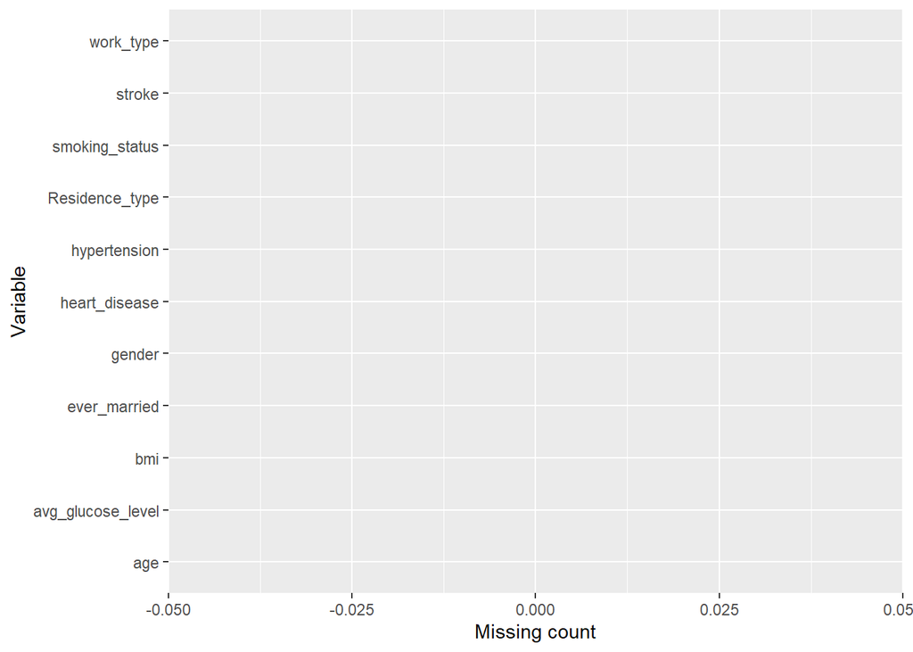

```r
df %>%
  summarise_all(funs(sum(is.na(.)))) %>%
  gather(key = "variable", value = "missing_count") %>%
  ggplot(aes(x = reorder(variable, missing_count), y = missing_count)) +
  geom_col() +
  coord_flip() +
  labs(x = "Variable", y = "Missing count")
```

Or we can view the missing values in a table

```r
df %>%
  summarise_all(funs(sum(is.na(.)))) %>%
  gather(key = "variable", value = "missing_count")
```

```
##             variable missing_count
## 1             gender             0
## 2                age             0
## 3       hypertension             0
## 4      heart_disease             0
## 5       ever_married             0
## 6          work_type             0
## 7     Residence_type             0
## 8  avg_glucose_level             0
## 9                bmi             0
## 10    smoking_status             0
## 11            stroke             0
```

We can also use the colSums function from the dplyr package to count the number of missing values in each column

```r
colSums(is.na(df))
```

```
##            gender               age      hypertension     heart_disease
##                 0                 0                 0                 0
##      ever_married         work_type    Residence_type avg_glucose_level
##                 0                 0                 0                 0
##               bmi    smoking_status            stroke
##                 0                 0                 0
```

Duplicate values

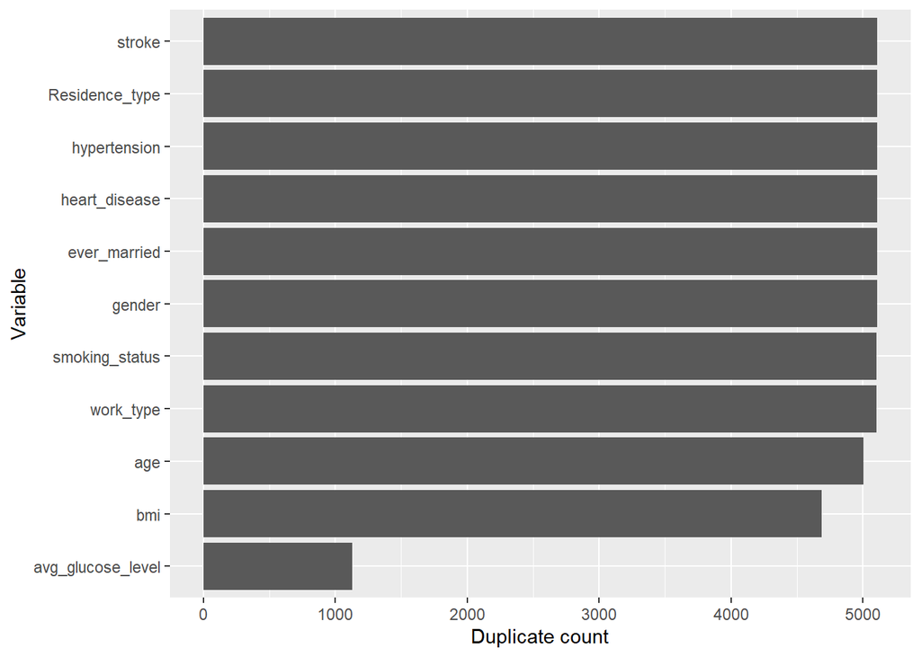

```r
df %>%
  summarise_all(funs(sum(duplicated(.)))) %>%
  gather(key = "variable", value = "duplicate_count") %>%
  ggplot(aes(x = reorder(variable, duplicate_count), y = duplicate_count)) +
  geom_col() +
  coord_flip() +
  labs(x = "Variable", y = "Duplicate count")
```

This is not right, I dont think we can have these many duplicates.. I will use the table function and the duplicated function as follows: I will Use the duplicated function to create a logical vector indicating which rows are duplicates. Set the fromLast argument to TRUE to include the first occurrence of each value in the count. Then use the table function to count the number of duplicates for each value.

```r
dup <- duplicated(df, fromLast = TRUE)
table(dup)
```

```
## dup
## FALSE
##  5110
```

The output `dup FALSE` 5110 indicates that there are no duplicate rows in our data frame. The duplicated function returns a logical vector indicating which rows are duplicates, with `TRUE` values indicating duplicate rows and `FALSE` values indicating unique rows. The table function counts the number of `TRUE` and `FALSE` values in the logical vector, which in this case indicates that there are 5110 unique rows (indicated by `FALSE` values) and no duplicate rows (indicated by `TRUE` values).

If we want to view the rows that are duplicates, I will use the `which` function to find the indices of the duplicate rows. For example:

```r
duplicate_rows <- which(dup)
duplicate_rows
```

```
## integer(0)
```

return all column names

```r
colnames(df)
```

```
##  [1] "gender"            "age"               "hypertension"
##  [4] "heart_disease"     "ever_married"      "work_type"
##  [7] "Residence_type"    "avg_glucose_level" "bmi"
## [10] "smoking_status"    "stroke"
```

## Remove rows with missing or invalid values Just in case

```r
df <- na.omit(df)
```

# Data Visualization

## Histograms

Age Distribution

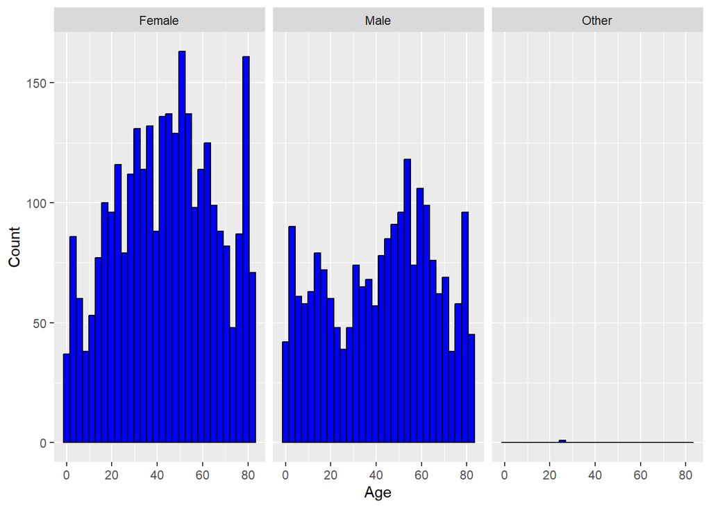

```r
ggplot(df, aes(x = age)) +
  geom_histogram(bins = 30, fill = "blue", color = "black") +
  labs(x = "Age", y = "Count") +
  facet_wrap(~gender)
```

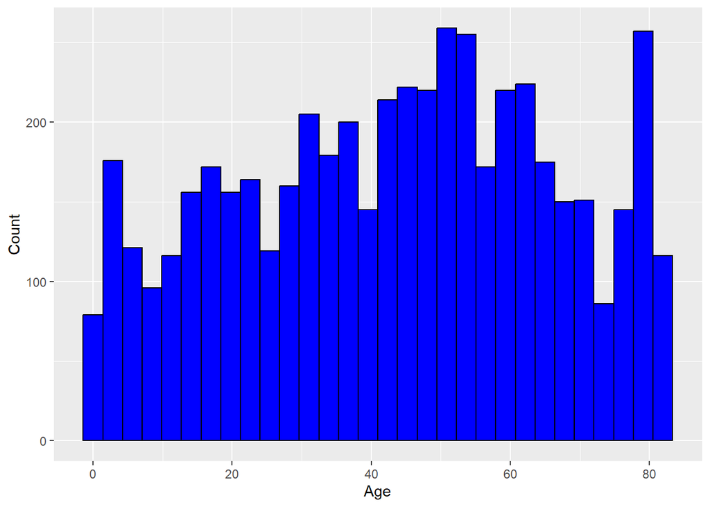

```r
ggplot(df, aes(x = age)) +
  geom_histogram(bins = 30, fill = "blue", color = "black") +
  labs(x = "Age", y = "Count")
```

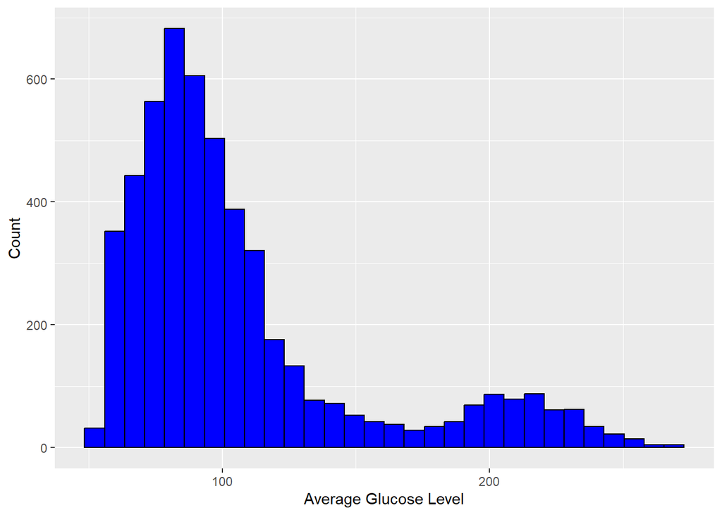

```r
ggplot(df, aes(x = avg_glucose_level)) +
  geom_histogram(bins = 30, fill = "blue", color = "black") +
  labs(x = "Average Glucose Level", y = "Count")
```

to hide warnings

```r
options(warn=-1)
```

Creating a bar plot for gender VS stroke

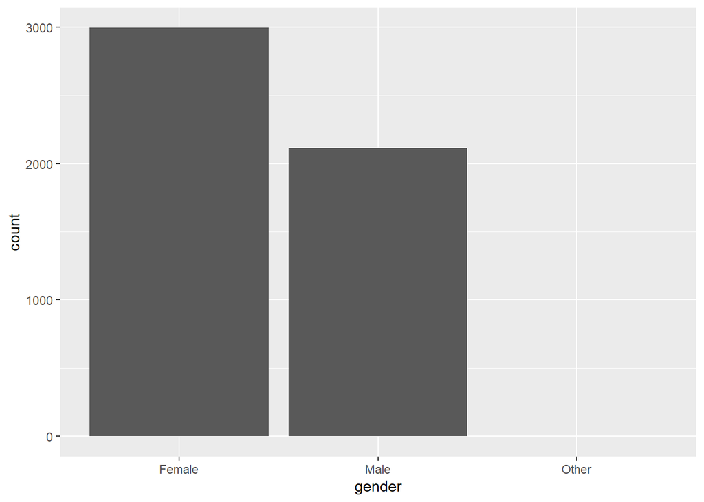

```r
ggplot(df,aes(x=gender,fill=stroke))+geom_bar(position="dodge")
```

creating a bar plot for hypertension vs stroke

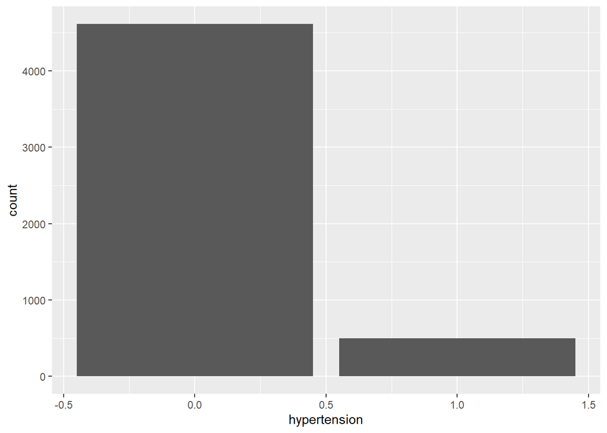

```r
ggplot(df,aes(x=hypertension,fill=stroke))+geom_bar(position="dodge")
```

Creating a bar plot for the smoking status and the stroke

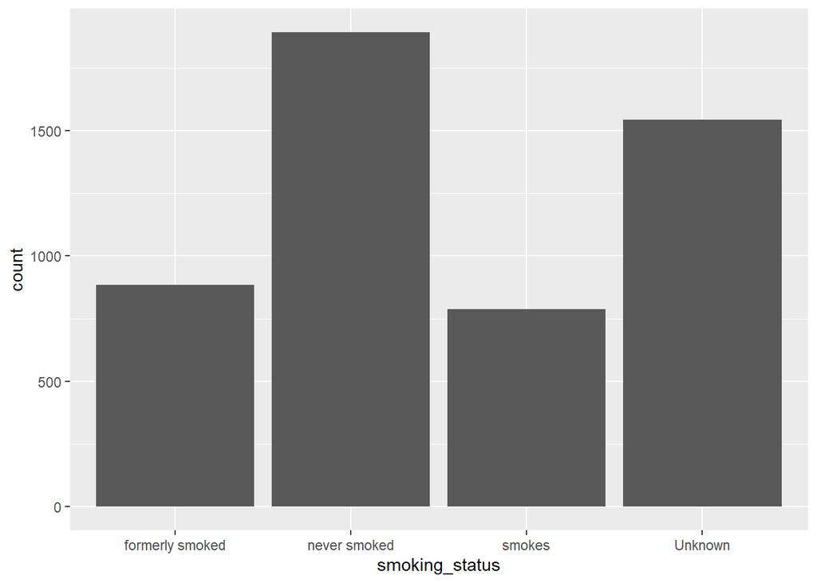

```r
ggplot(df,aes(x=smoking_status,fill=stroke))+geom_bar(position = "dodge")
```

## Boxplots

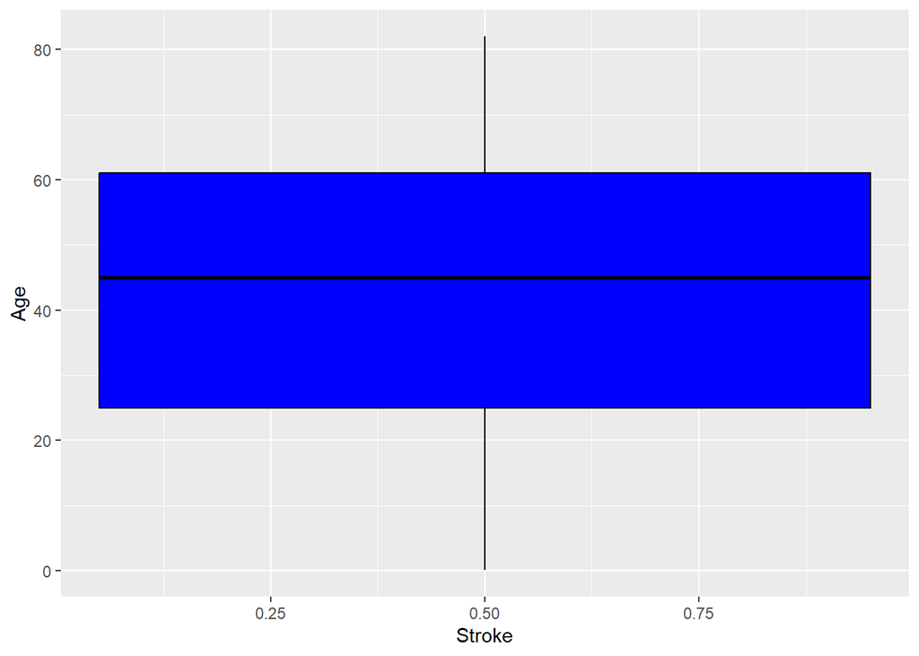

```r
ggplot(df, aes(x = stroke, y = age)) +
  geom_boxplot(fill = "blue", color = "black") +
  labs(x = "Stroke", y = "Age")
```

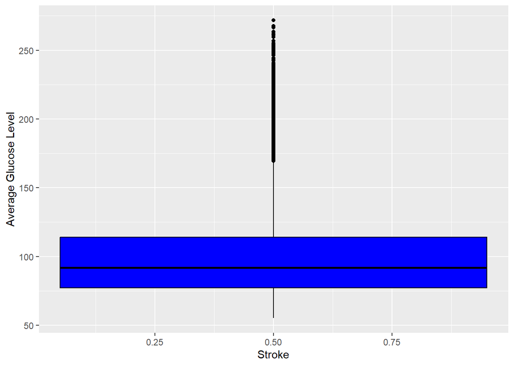

```r
ggplot(df, aes(x = stroke, y = avg_glucose_level)) +
    geom_boxplot(fill = "blue", color = "black") +
    labs(x = "Stroke", y = "Average Glucose Level")
```

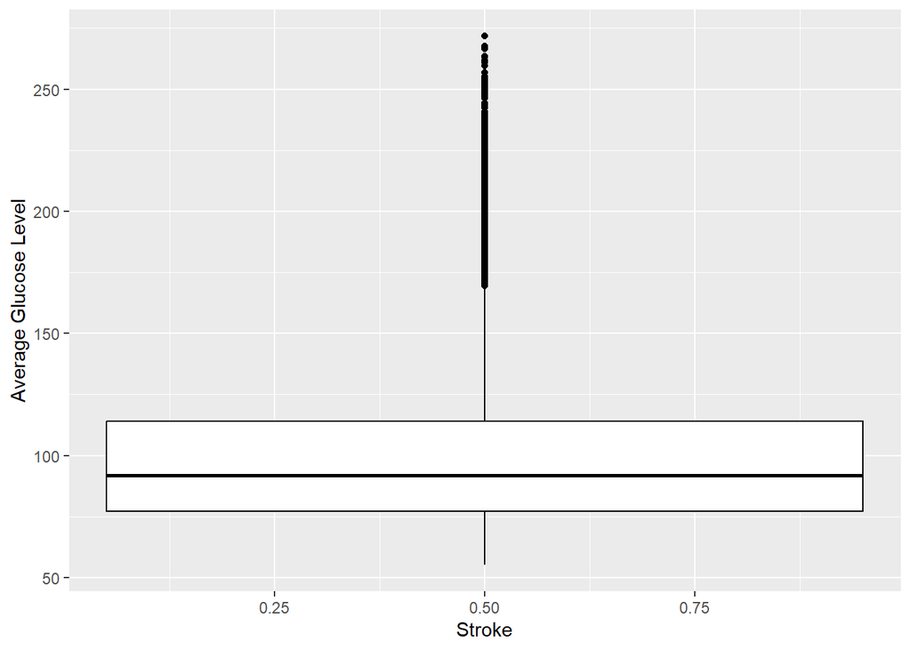

```r
ggplot(df, aes(x = stroke, y = avg_glucose_level, fill = stroke)) +
  geom_boxplot(color = "black") +
  labs(x = "Stroke", y = "Average Glucose Level")
```

Comparing the proportions within the gender among the people who got stroke

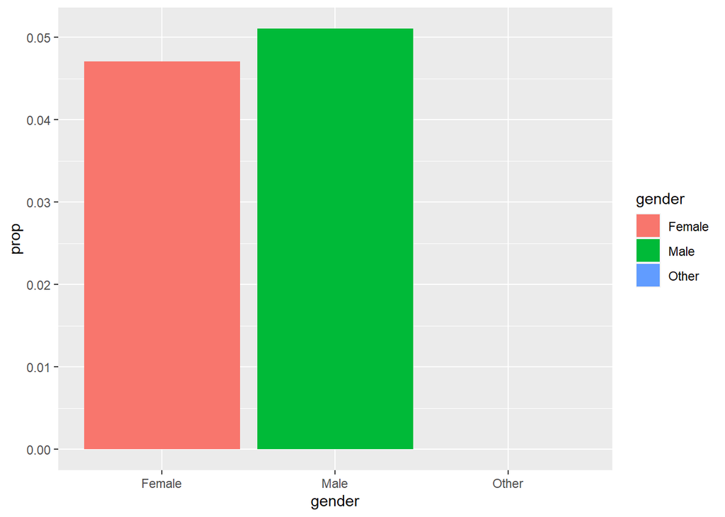

```r
data_proportion_gender<- df %>%
                  group_by(gender)%>%
                  summarise(prop=sum(stroke==1)/length(gender))

g1<-ggplot(data_proportion_gender,aes(x=gender,y=prop,fill=gender))+geom_col()
g1
```

comparing the proportions within the different married type who got stroke

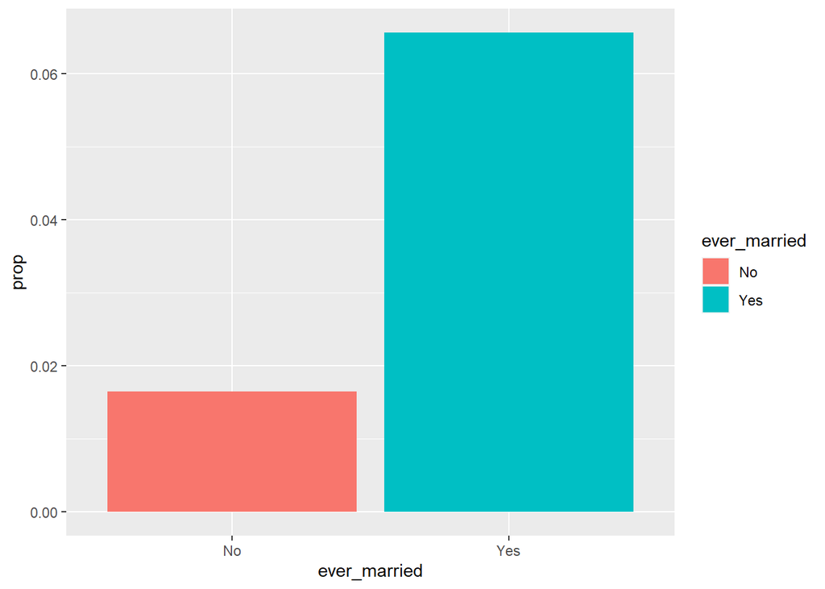

```r
data_proportion_married<- df%>%
                          group_by(ever_married)%>%
                          summarise(prop=sum(stroke==1)/length(ever_married))

g2<-ggplot(data_proportion_married,aes(x=ever_married,y=prop,fill=ever_married))+geom_col()
g2
```

Comparing the proportions of people who have hypertension who got stroke

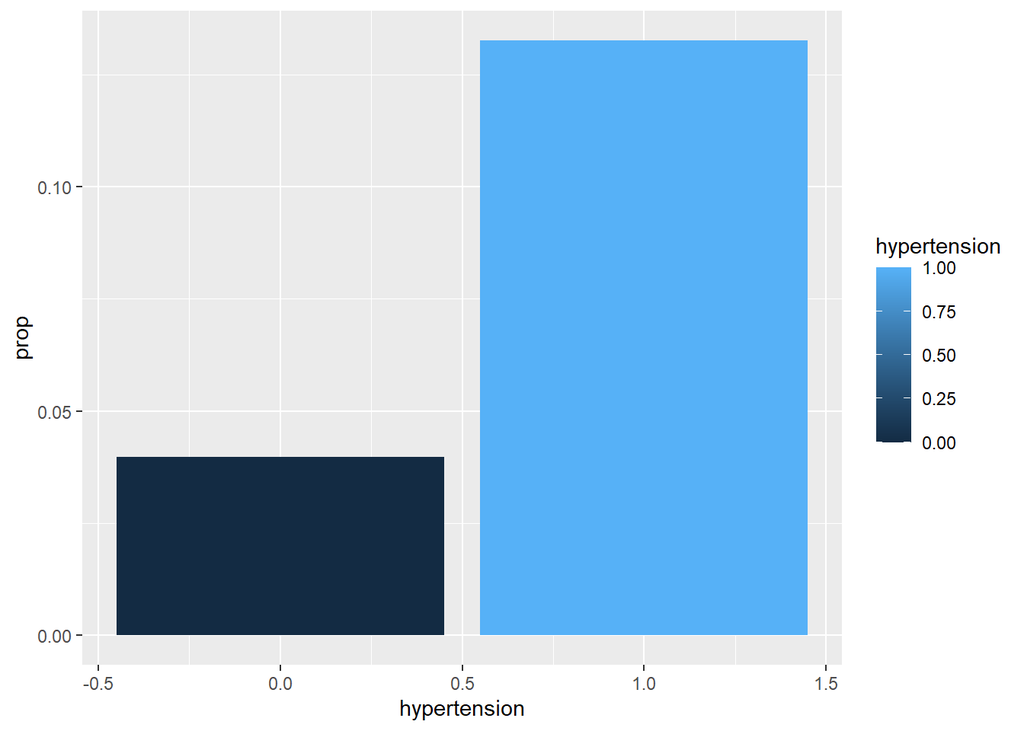

```r
data_proportion_hypertension<- df%>%
  group_by(hypertension)%>%
  summarise(prop=sum(stroke==1)/length(hypertension))

g3<-ggplot(data_proportion_hypertension,aes(x=hypertension,y=prop,fill=hypertension))+geom_col()
g3
```

Comparing the proportions of people who have the heart diseases who got stroke

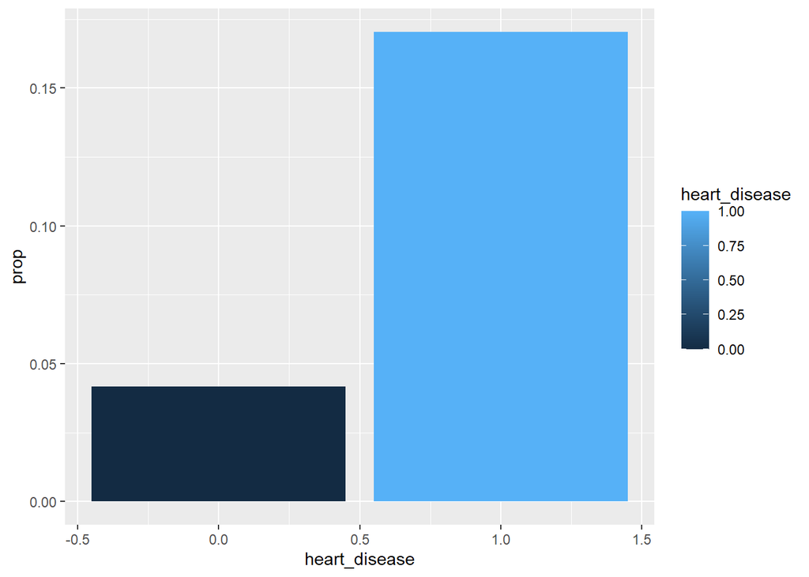

```r
data_proportion_heart_disease<- df%>%
  group_by(heart_disease)%>%
  summarise(prop=sum(stroke==1)/length(heart_disease))

g4<-ggplot(data_proportion_heart_disease,aes(x=heart_disease,y=prop,fill=heart_disease))+geom_col()
g4
```

Comparing the proportions of people who have different worktype who got a stroke

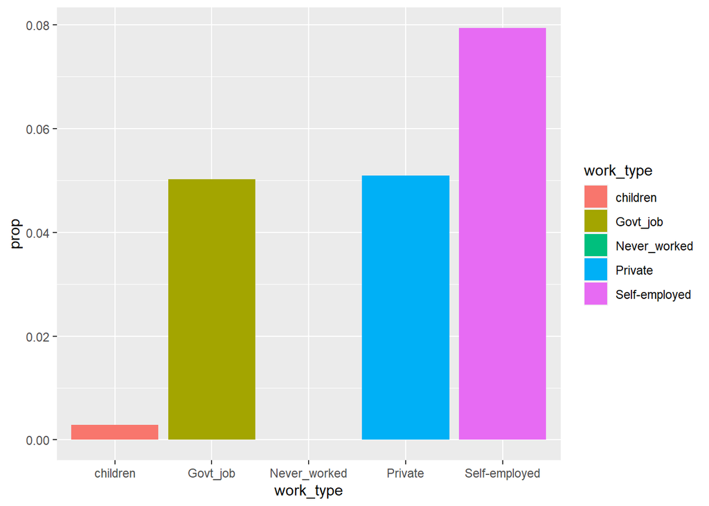

```r
data_proportion_work_type<- df%>%
  group_by(work_type)%>%
  summarise(prop=sum(stroke==1)/length(work_type))

g5<-ggplot(data_proportion_work_type,aes(x=work_type,y=prop,fill=work_type))+geom_col()
g5
```

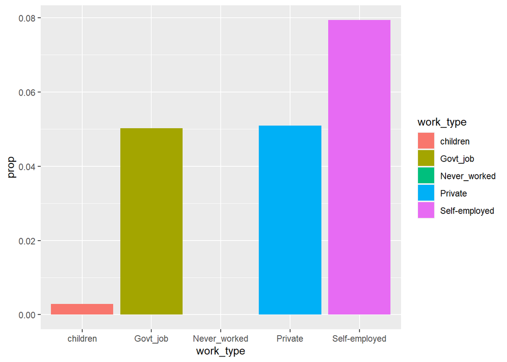

```r
data_proportion_Residence_type<- df%>%
  group_by(Residence_type)%>%
  summarise(prop=sum(stroke==1)/length(Residence_type))

g6<-ggplot(data_proportion_Residence_type,aes(x=Residence_type,y=prop,fill=Residence_type))+geom_col()
g5
```

comparing people with different smoking status type who got stroke

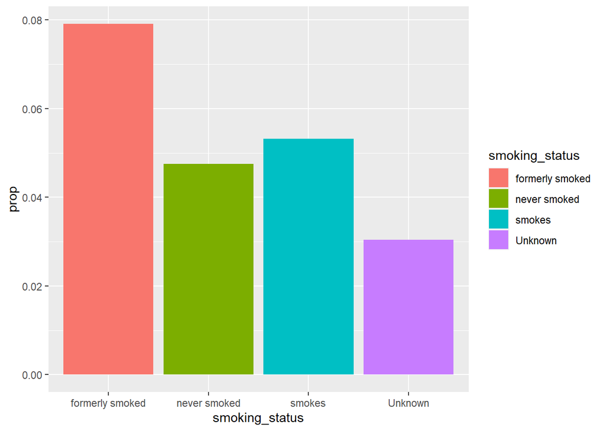

```r
data_proportion_smoking_status<- df%>%
  group_by(smoking_status)%>%
  summarise(prop=sum(stroke==1)/length(smoking_status))


g7<-ggplot(data_proportion_smoking_status,aes(x=smoking_status,y=prop,fill=smoking_status))+geom_col()
g7
```

Plotting together in the form of a grid

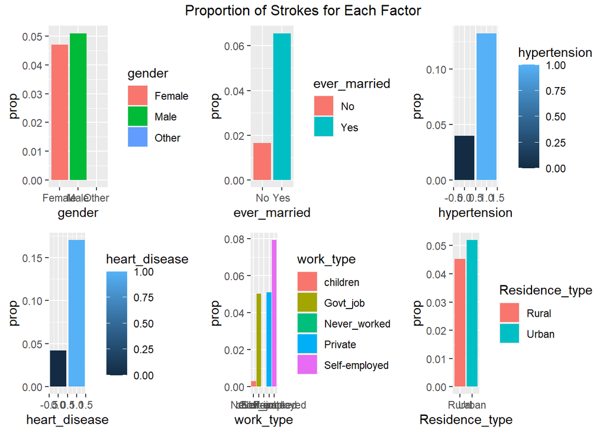

```r
grid.arrange(grobs=list(g1,g2,g3,g4,g5,g6),ncol=3, top = "Proportion of Strokes for Each Factor")
```

Comparing the boxplot for different factors with age

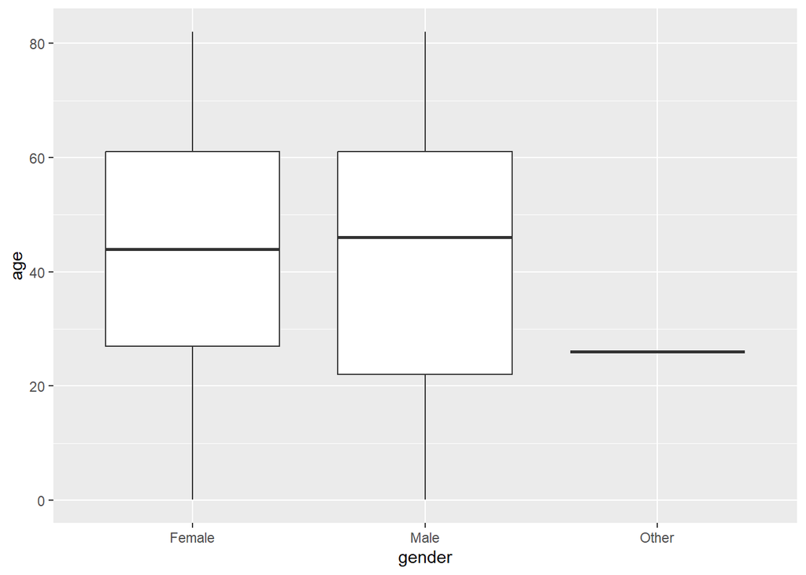

```r
b1<-df %>%
    ggplot(aes(x=gender,y=age,color=stroke))+geom_boxplot()
b1
```

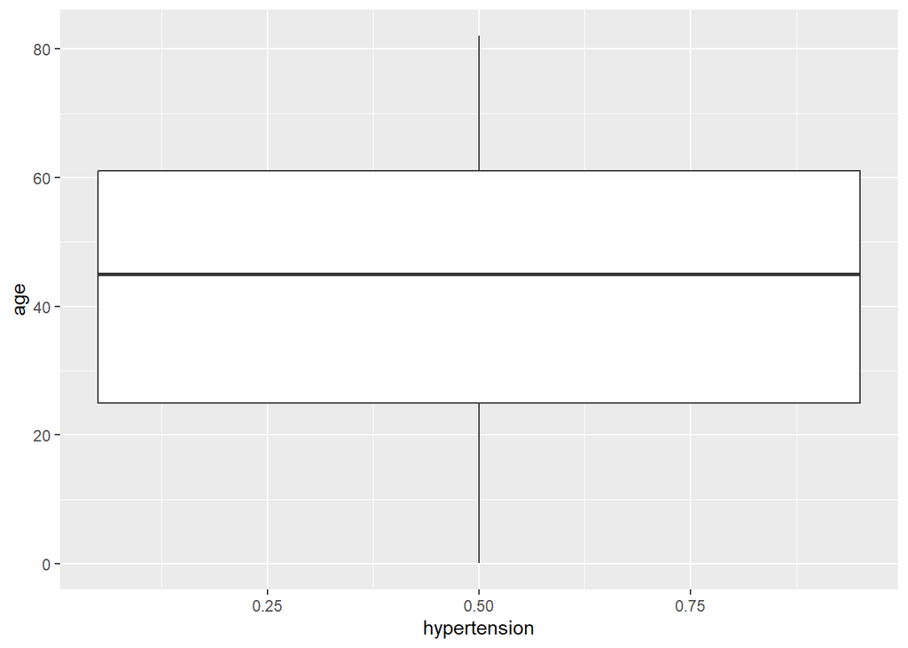

```r
b2<-df %>%
  ggplot(aes(x=hypertension,y=age,color=stroke))+geom_boxplot()
b2
```

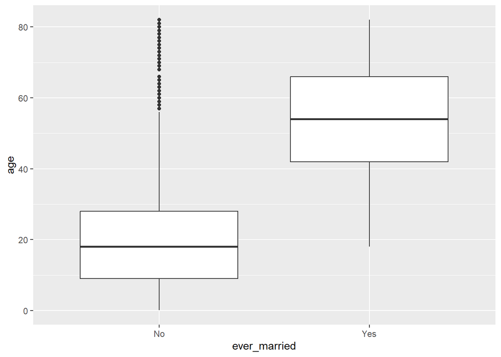

```r
b3<-df %>%
  ggplot(aes(x=ever_married,y=age,color=stroke))+geom_boxplot()
b3
```

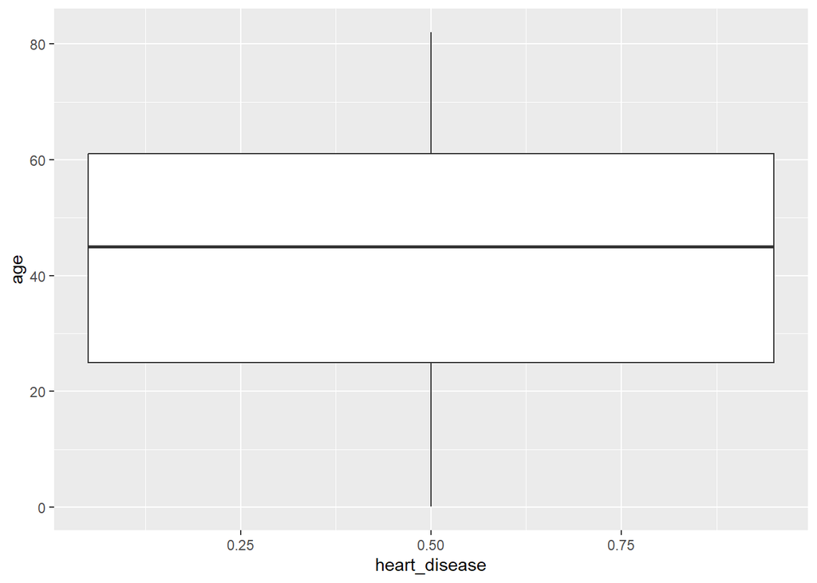

```r
b4<-df %>%
  ggplot(aes(x=heart_disease,y=age,color=stroke))+geom_boxplot()
b4
```

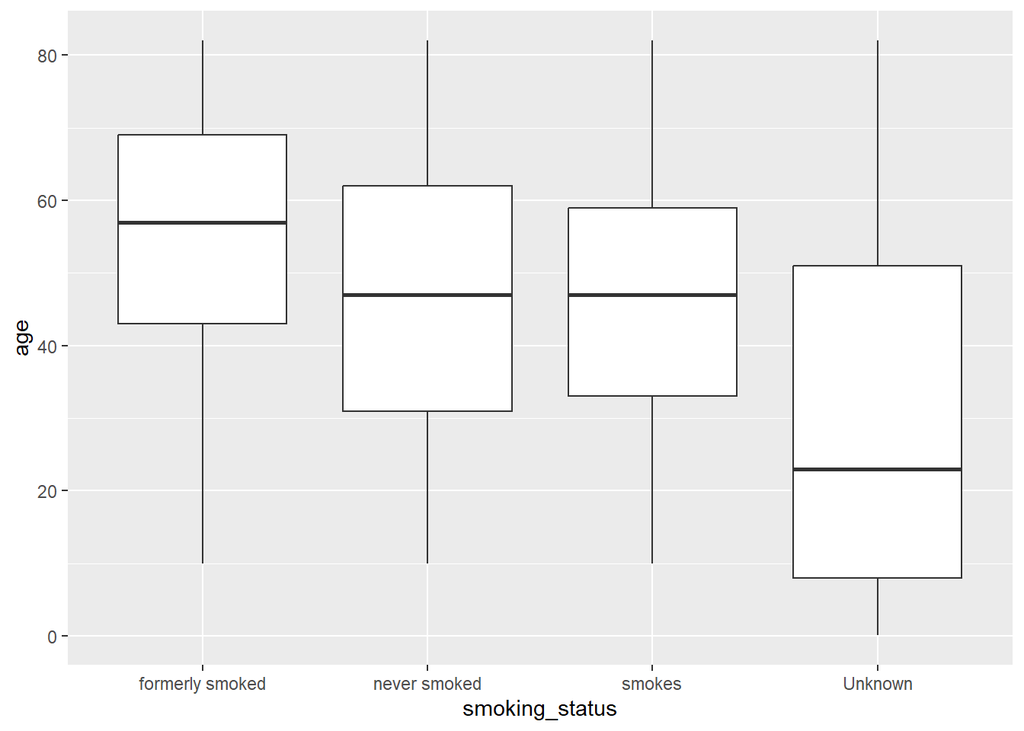

```r
b5<-df %>%
  ggplot(aes(x=smoking_status,y=age,color=stroke))+geom_boxplot()
b5
```

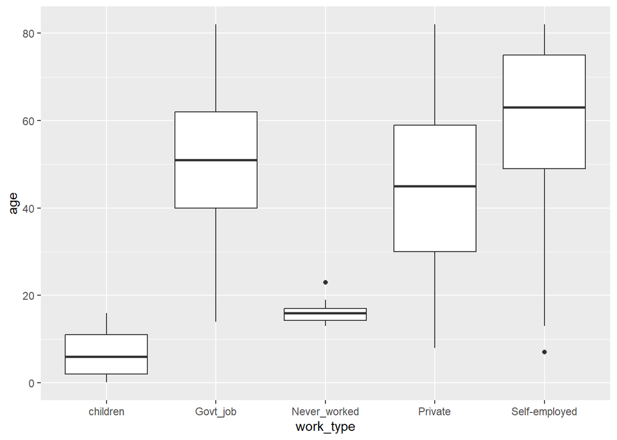

```r
b6<-df %>%
  ggplot(aes(x=work_type,y=age,color=stroke))+geom_boxplot()
b6
```

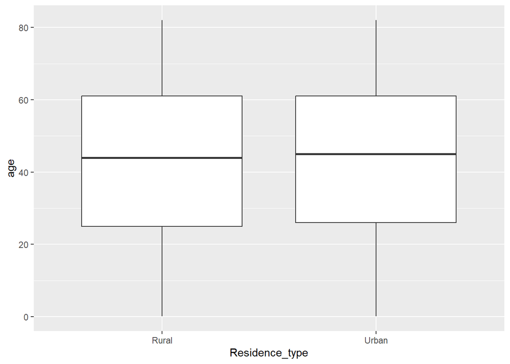

```r
b7<-df %>%
  ggplot(aes(x=Residence_type,y=age,color=stroke))+geom_boxplot()
b7
```

Comparing the strokes for glucose level across various factors

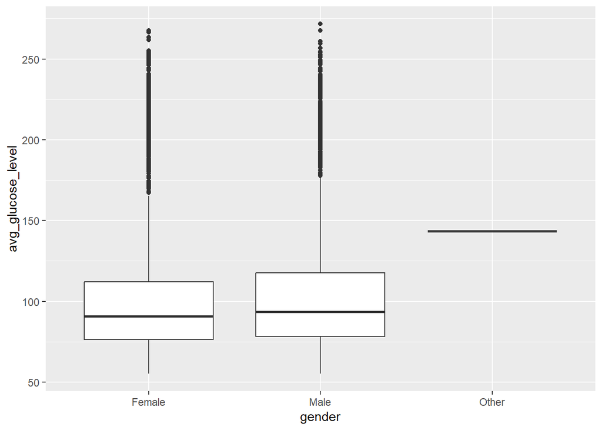

```r
q1<-df %>%
  ggplot(aes(x=gender,y=avg_glucose_level,color=stroke))+geom_boxplot()
q1
```

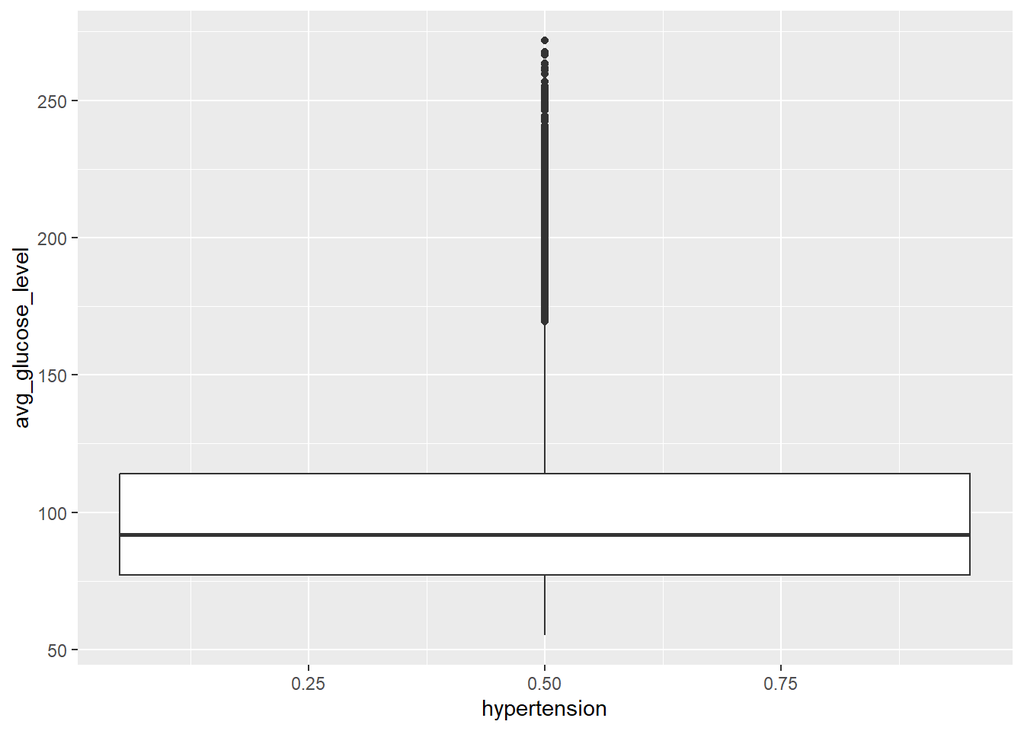

```r
q2<-df %>%
  ggplot(aes(x=hypertension,y=avg_glucose_level,color=stroke))+geom_boxplot()
q2
```

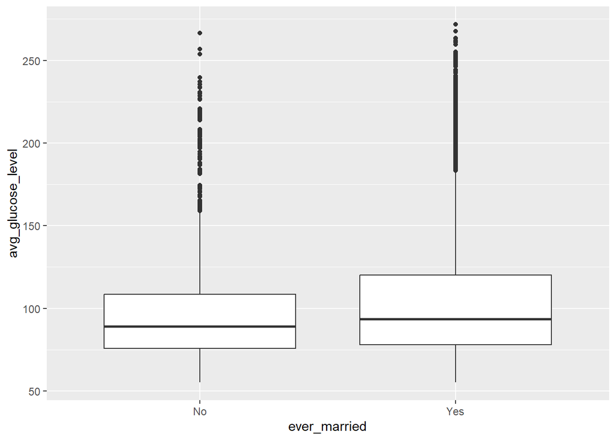

```r
q3<-df %>%
  ggplot(aes(x=ever_married,y=avg_glucose_level,color=stroke))+geom_boxplot()
q3
```

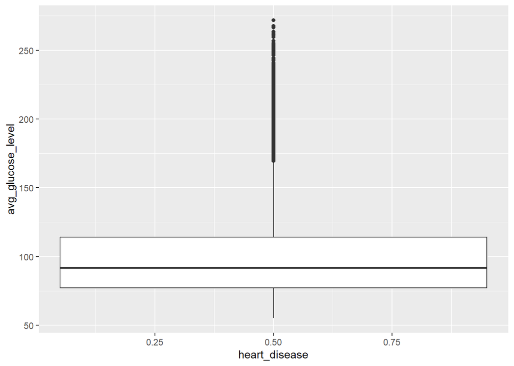

```r
q4<-df %>%
  ggplot(aes(x=heart_disease,y=avg_glucose_level,color=stroke))+geom_boxplot()
q4
```